# Noncoding RNA Set Cis Annotation and Enrichment

# Pathway Enrichment

As in GO enrichment analysis, pathway enrichment analysis can be performed based on gene neigbourhood, predicted targets, correlation coefficient and/or topological domain analysis. Each parameter is controlled by the related parameters and HUGO, ENSEMBL gene, ENSEMBL transcript gene, ENTREZ ID and miRNA name is supported for the input gene list. Non-coding genes can be annotated and enriched with KEGG, Reactome and Wiki pathways. Moreover, pathway enriched can be performed based on custom GMT file. GMT file supports both gene format of ENTREZ ID, Symbol and it is controlled by the `isSymbol` parameter. `genePathwayEnricher` and `geneRegionPathwayEnricher` functions fulfill the pathway enrichment for the genes and regions expect the miRNA genes and for the miRNA `mirnaPathwayEnricher` and `mirnaRegionPathwayEnricher` is used.

```r
#Pathway enrichment based on the gen sets that falls into the TAD regions
ncRNAPathway<-genePathwayEnricher(gene = brain_disorder_ncRNA[1:500,], hg='hg19', pathwayType = 'kegg', isTADSearch = TRUE,TAD = tad_hg19, genetype = 'Ensembl_gene', min=2)
```

```r
#Pathway enrichment using custom database
nc2 <- genePathwayEnricher(gene = brain_disorder_ncRNA, hg = 'hg19', pathwayType = 'other', near = TRUE, genetype = 'Ensembl_gene',  min = 2, gmtName = 'Human_AllPathways_March_01_2019_entrezgene.gmt', isSymbol = FALSE)
```

# Gene Enrichment Analysis

As a part of pathway analysis, NoRCE carries out hypergeometric test on/gene enrichment of a set of noncoding genes based on gene neigbourhood, target prediction, correlation coefficient and/or topological domain analysis for a given population coding gene set. Genes that form the population set should be provided with `gmtName` and population dataset should be data frame.

```r
a <-mirnaPathwayEnricher(gene = brain_mirna, hg = "hg19", near = TRUE, gmtName = brain_gene, isSymbol = TRUE, isGeneEnrich = TRUE, pathwayType = "other")
```

# Pre-processing Steps

## Filter ncRNA Genes Based on Biotype Subsets

Specific biotype of RNA have different characteristics. Biotype information of each gene is provided in [GENCODE](https://www.gencodegenes.org/pages/biotypes.html) as a .GTF format for human and mouse genomes. `filterBiotype` in [NoRCE](https://github.com/guldenolgun) extracts the genes according to the given biotypes and curates the input list accordingly.

```r
#Load differentially expressed non-coding genes
data("brain_disorder_ncRNA")

biotypes <- c('lincRNA','antisense')

#It is suggested to use Zip format of the GENCODE gtf file
lncGenes <-filterBiotype(gtfFile = "pathTotheGTFFile//gtf", biotypes = biotypes)

#All of the lincRNA and antisense genes are carried out to the GO enrichment analysis
lncEnrich<-geneGOEnricher(gene = unique(lncGenes), hg = "hg19", genetype = "Ensembl_gene")

#Find lincRNA and antisense lncRNAs in the given input list and perform enrichment
lncEnrich<-geneGOEnricher(gene = intersect(lncGenes$gene,brain_disorder_ncRNA$V1), hg = "hg19", genetype = "Ensembl_gene")
```

## Co-expression Analysis

Pre-calculated Pearson correlation coefficient values based on TCGA data or correlation coefficient values measured from the user data can be used for filtering the gene list that are used for annotation and enrichment or applying annotation and enrichment analysis for using only co-expression analysis. Final set is determined by curating the gene list for a given p-value, correlation threshold and p-Adjusted-value.

### Co-expression Analysis in The Cancer Genome Atlas

`corrbased` provides pre-measured Pearson correlation between lncRNA-mRNA and miRNA-mRNA interactions. Input list can be curated with the miRNA or lncRNA gene sets whose correlation values exceed the given threshold. Gene expressions are gathered from TCGA. In order to run this part, [miRCancer.db](https://figshare.com/articles/miRCancer_db_gz/5576329) database must be downloaded locally.

```r
#Load miRNA gene set
data("brain_mirna")

database<- "filePathOfTheDatabase//miRCancer.db"

brcaCorr<- corrbased(mirnagene = brain_mirna, cancer = 'BRCA', minAbsCor = 0.3, database)
```

Input list can also be a set of mRNA to allow enrichment analysis of miRNAs that are correlated with those mRNAs.

```r
data("breastmRNA")

database<- "filePathOfTheDatabase//miRCancer.db"

breast_corr<-corrbasedMrna(mRNAgene = as.data.frame(breastmRNA),cancer = 'BRCA', minAbsCor = 0.3, database)

corr_miRNAEnrichment<-mirnaGOEnricher(gene=breast_corr$mirna_base,hg='hg38',near = TRUE,target = FALSE)
```

### Co-expression Analysis in Custom Expression Data

Correlation coefficient values between two custom expression data can be calculated and possible interactions can be identified with a predefined threshold filtering in NoRCE. `calculateCorr` function takes two custom data and calculate the correlation between two genes by using correlation method that is defined by the `corrMethod` parameter. It curates the genes based on the cut-offs of the p-value, correlation value and p-Adjusted-value.

```r
#Assume that mirnanorce and mrnanorce are custom patient by gene data

dataCor <- calculateCorr(exp1 =  mirna, exp2 = mrna)
```

## Visualization

Results can be finalized in a tabular format or with relevant graphs. Some plots are available only for the GO enrichment analysis, and some of them are available only for the pathway enrichment.

### Tabular Format

Information about the enrichment result can be written down in a tabular format as a txt file. Results are sorted according to the p-value or p-adjusted-value and all of the enrichment results or user defined number of top enrichment can be written down. This function is suitable for both GO and pathway enrichment.

```r
ncGO<-geneGOEnricher(gene = brain_disorder_ncRNA, hg='hg19', near=TRUE, genetype = 'Ensembl_gene', searchRegion = "exon", slim = FALSE, pAdjust = "none")
writeEnrichment(mrnaObject = ncGO, fileName = 'enrichment.txt', sept = '\t',type = 'pvalue')

#Top 10 enrichment results are written
writeEnrichment(mrnaObject = ncGO, fileName = 'enrichment.txt', sept = '\t',type = 'pvalue', n=10)
```

### Dot Plot

Dot plot for the given number of top enrichments can be utilized for further analysis. In the dot plot, number of overlapped genes that are annoted with the enriched GO-term and occur in the input list, p-value or p-value adjustment value for the selected correction method per GO or pathway is provided.

[figure not shown]

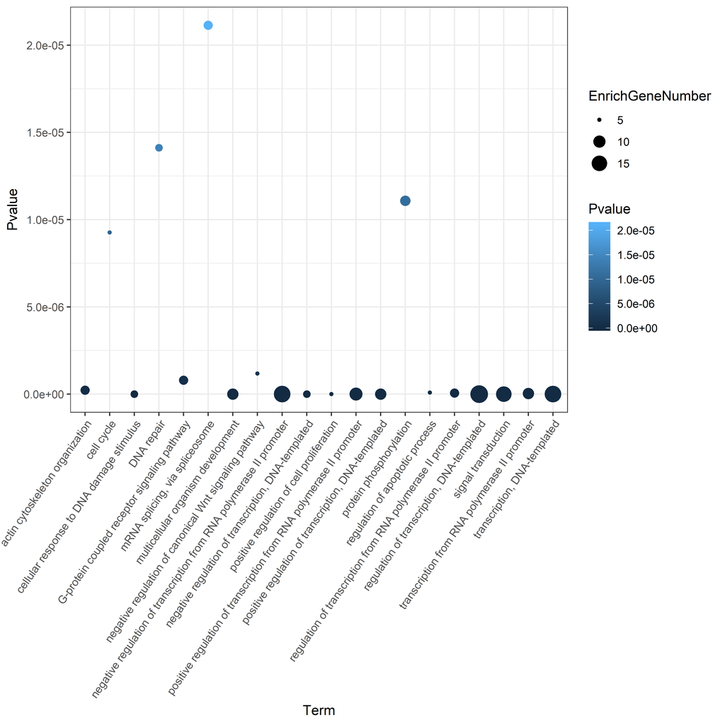

```r
ncGO<-geneGOEnricher(gene = brain_disorder_ncRNA, hg='hg19', near=TRUE, genetype = 'Ensembl_gene', searchRegion = "exon", slim = FALSE, pAdjust = "none")

drawDotPlot(mrnaObject = ncGO, type = 'pvalue', n = 20)
```

### GO:mRNA Network

Relationship between top enriched GO-terms and mRNA genes are shown in an undirected network. `isNonCode` parameter checks whether list of enriched noncoding genes will be employ for the node name. Node name decision for the GO-term or GO-ID is determined by the `takeID` parameter. For the node name decision for the GO-term, parameter must set to the `FALSE`.

```r
ncGO<-geneGOEnricher(gene = brain_disorder_ncRNA, hg='hg19', near=TRUE, genetype = 'Ensembl_gene', searchRegion = "exon", slim = FALSE, pAdjust = "none")

createNetwork(mrnaObject = ncGO, type = 'pvalue', n =3)
```

[figure not shown]

```r
createNetwork(mrnaObject = ncGO, type = 'pvalue', n = 3, isNonCode = FALSE,takeID = TRUE)
```

[figure not shown]

[figure not shown]

### GO:ncRNA Gene Network

Relationship between top enriched GO-terms and noncoding genes are shown in an undirected network. `isNonCode` parameter checks whether list of enriched noncoding genes will be employed for the node name. Node name decision for the GO-term or GO-ID is determined by the `takeID` parameter. For the node name decision for the GO-term, parameter must set to the `FALSE`.

```r
ncGO<-geneGOEnricher(gene = brain_disorder_ncRNA, hg='hg19', near=TRUE, genetype = 'Ensembl_gene', searchRegion = "exon", slim = FALSE, pAdjust = "none")

createNetwork(mrnaObject = ncGO, type = 'pvalue', n = 3, isNonCode = TRUE,takeID = TRUE)
```

[figure not shown]

### GO DAG Network

Directed acyclic graph of the top enriched GO-terms can be illustareted with the `getGoDag` function. Enriched GO-terms are marked with a range of color based on the p-value or p-adjusted-value. P-value ranges can be changed with the `p_range` parameter.

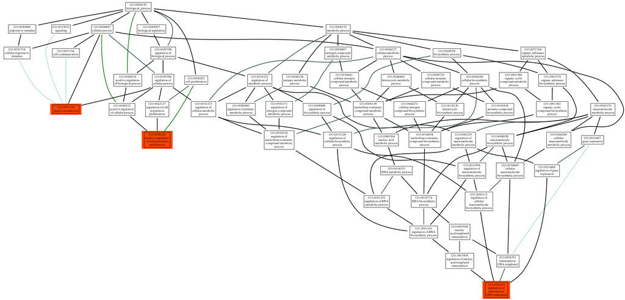

```r
ncGO<-geneGOEnricher(gene = brain_disorder_ncRNA, hg='hg19', near=TRUE, genetype = 'Ensembl_gene', searchRegion = "exon", slim = FALSE, pAdjust = "none")

getGoDag(mrnaObject = ncGO, type = 'pvalue', n =3, filename = 'gonetwork.png',imageFormat = 'png')
```

### KEGG and Reactome Pathway Map

Map of the enriched pathways can be demonstrated in the browser. Due to the limitation of the pathways, each pathway should be treated separately for the pathway map. Moreover, matching genes in the enrichment gene set for the corresponding pathway are marked with color.

[figure not shown]

```r
ncRNAPathway<-mirnaPathwayEnricher(gene = brain_mirna[1:100,], hg='hg19',target = TRUE)

#For the enriched pathway hsa04742, pathway map is created
getKeggDiagram(mrnaObject = ncRNAPathway, hg = 'hg19',pathway = ncRNAPathway@ID[1])
```

[figure not shown]

```r
miPath<-mirnaPathwayEnricher(gene=brain_mirna,hg='hg38',target=TRUE, pathwayType = 'reactome')

getReactomeDiagram(mrnaObject = miPath, pathway = miPath@ID[1], imageFormat = 'png')
```

# Citation